# Figure de Chladni

Mini-projet EDP - Figures de Chladni

*Projet réalisé par Tony WU*

*Contact : tony.wu@student-cs.fr*

[figure not shown]

**Source :** https://www.pourlascience.fr/sd/physique/lholographie-au-secours-des-luthiers-14192.php

**Modules à installer au préalable :**

- feniCS (2019)
- mshr
- numpy
- MatPlotLib
- ipywidgets

```python
from __future__ import print_function
from fenics import *
from mshr import *
import math as m
import cmath
import numpy as np
import matplotlib.pyplot as plt
import ipywidgets as widgets
from ipywidgets import interact, interact_manual
from IPython.display import YouTubeVideo

import os
from datetime import datetime
```

```python
os.getcwd()
```

```
'/Users/Tony/Desktop/Projet EDP (FeniCS)/Figure de Chladni - Tony WU'
```

# Modélisation

## Obtention de l'EDP par la Physique

Pour respecter la longueur maximale du devoir, cette partie a été déplacée en **Annexe**, en fin de notebook. Nous admettrons donc ici que l'amplitude de déformation du matériau notée $z$ vérifie l'**équation d'onde** dite *de D'Alembert* :

\begin{equation} \Delta z - \frac{1}{c^{2}} \frac{\partial^{2} z}{\partial t^{2}}=0 \end{equation}

avec $c$ définie également en **Annexe**.

## Simplification du problème et obtention d'une équation elliptique

En outre, comme les 2 opérateurs jouent respectivement uniquement sur les variables d'espace et sur la variable de temps. Nous pouvons utiliser la méthode de séparation des variables en supposant u de la forme suivante : \begin{equation} z(x,y,t) = u(x,y) \times g(t) \end{equation}

En réinjectant dans l'équation précédente, on tire :  
\begin{equation} \Delta u (x,y) \times g(t) = \frac{1}{c^2} u(x,y) \frac{d^2 g}{dt^{2}}(t) \end{equation}

On regroupe alors à gauche les u et à droite les g : \begin{equation} \frac{\Delta u (x,y)}{u(x,y)} = \frac{1}{c^2} \frac{1}{g(t)} \frac{d^2 g}{dt^{2}}(t) \end{equation}

Commes les 2 membres sont chacun fonctions de variables indépendantes, on en déduit qu'ils sont égaux à une constante notée $\lambda$, homgène à l'inverse d'une longueur au carré : \begin{equation} \forall (x,y) \in \Omega, \frac{\Delta u (x,y)}{u(x,y)} = \lambda \tag{1}\\ \end{equation} \begin{equation} \forall t, \frac{1}{c^2} \frac{1}{g(t)} \frac{d^2 g}{dt^{2}}(t) = \lambda \tag{2}\\ \end{equation}

**On se restreindra à l'étude de (1)**, l'EDO (2) se résolvant facilement avec l'utilisation de l'équation caractéristiques.

### Condition au bord $\partial \Omega$

Ceci revient à supposer que **les bords du domaine sont fixés et ne peuvent donc pas vibrer**.

### Défintion du domaine $\Omega$

Pour les parties 3 et 4, nous nous restreindrons à un **domaine carré** $\Omega = [-1,1] \times [-1,1]$.  
Pour les parties 5, 6 et 7, nous construirons un **domaine régulier polyédrique** qui s'appuiera sur la forme d'un corps de guitare.

# Préliminaires

## Adimensionnement de l'équation

On pose les grandeurs adimensionnées suivantes :

\begin{equation} X=\frac{x}{L} \times N, \quad Y=\frac{y}{L} \times N, \quad U(X, Y)=u(x, y) \end{equation}

L'équation vérifiée par $U(X, Y)$ peut donc se mettre sous la forme : \begin{equation} \Delta U=\frac{\partial^{2} U}{\partial X^{2}}+\frac{\partial^{2} U}{\partial Y^{2}}=-\lambda \cdot U \tag{$E_{adim}$}\\ \end{equation}

## Formulation Faible (FF)

Soit $v \in \mathcal{D}(\mathring{\overset{\frown}{\Omega}})$. On mulitplie l'équation $(E_{adim})$ par v, ce qui donne : \begin{equation} \Delta U = -\lambda U v \end{equation}

On intègre ensuite sur $\Omega$ : \begin{equation} \int_{\Omega} (\Delta U) v = - \int_{\Omega}\lambda U v \end{equation}

On rappelle la *formule d'intégration par parties généralisée* qu'on applique juste après : \begin{equation} \int_{\Omega}(\Delta U) v=-\int_{\Omega} \nabla U \cdot \nabla v + \int_{\partial \Omega} v \nabla U \cdot n \end{equation}

Grâce aux conditions limites, le deuxième terme du membre de droite est en fait nul. On tire ainsi : \begin{equation} \int_{\Omega} (\nabla U \cdot \nabla v - \lambda U v) \tag{FF} = 0\\ \end{equation}

## Formulation Variationnelle (FV)

- **Choix d'un espace de Hilbert adapté à notre problème :**  
  On prend :  
  \begin{equation} \mathcal{H} = \mathcal{H_0^1} \end{equation}
- On pose les fonctions suivantes :

\begin{array}{l|rcl} a : & \mathcal{H_0^1} \times \mathcal{H_0^1} & \longrightarrow & \mathbb{R} \\ & (u,v) & \longmapsto & \int_{\Omega} (\nabla U \cdot \nabla v - \lambda U v) \\ \end{array}\begin{array}{l|rcl} L : & \mathcal{H_0^1} & \longrightarrow & \mathbb{R} \\ & (v) & \longmapsto & \int_{\Omega}\lambda U v \tag{FF}\\ \end{array}

Ainsi la formulation faible se réécrit ainsi : \begin{equation} a(U, v) = L(v) \tag{FV} \end{equation}

- On remarque que $a$ est une **forme bilinéaire**. La preuve pour la **continuité** et la **coercivité** de $a$ suit presque intégralement celle du cours en utilisant l'*Inégalité de Cauchy-Scharz* et l'*Inégalité de Poincarré* (non détaillée ici).  
  De même, on peut montrer que $L$ est **continue**.
- On peut alors appliquer le *théorème de Lax-Milgram* qui nous garantit que le problème variationnel possède une unique solution $v \in \mathcal{D}(\mathring{\overset{\frown}{\Omega}})$.

**Ressource supplémentaire :**

```python
YouTubeVideo('wvJAgrUBF4w')
```

[video not shown]

# Résolution numérique de l'EDO sur un domaine simple

## Espaces test et fonction

### Domaine

```python
domain = Rectangle(Point(-1., -1.), Point(1., 1.))
mesh = generate_mesh(domain, 150)

V = FunctionSpace(mesh, 'P', 2)
```

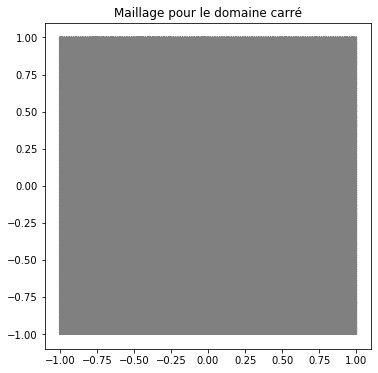

```python
plt.figure(figsize=(6,6))
plt.title('Maillage pour le domaine carré')
plot(mesh)
```

### Conditions limites

Nous prendrons ici une expression quelconque des conditions aux bords du problème.

```python
# Le choix de la valeur sur les bords est arbitraire, il faut juste imposer une Condition Limite non nulle pour
# ne pas retomber sur la solution nulle !
# Néanmoins, il s'avère que pour avoir une "jolie" représentation dans ParaView, imposer une valeur aux bords
# O.1 est nécessaire !
u_0 = Constant(0.1)

def boundary(x, on_boundary):
    return on_boundary

bc = DirichletBC(V, u_0, boundary)
```

Remarquons que pour respecter les notations de variable de FeniCS, nous désignerons $(x,y)$ par le nom de variable `x`.

### Résolution numérique

```python
lambda0 = 100 # et non pas lambda qui est déjà un mot clé en Python !
```

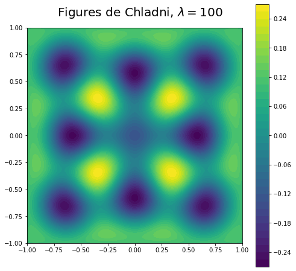

```python
# Définition du problème variationnel
u = TrialFunction(V)
v = TestFunction(V)

f = Constant(-1.0)

a = (dot(grad(u), grad(v)) - lambda0 * u * v) * dx
L = f*v*dx

eq = (dot(grad(u), grad(v)) - lambda0 * u * v) * dx

a = lhs(eq)
L = rhs(eq)

w = Function(V)

solve(a == L, w, bc)

plt.figure(figsize=(8,8))
c = plot(w)
plt.colorbar(c)
plt.suptitle(f'Figures de Chladni, $\lambda ={lambda0}$', x=0.45, y=0.875, fontsize=20)


filename = f'plaque_simple_lambda={lambda0}'

# Création d'un objet permettant de garder en mémoire le moment d'exécution de la fonction.
now = datetime.now()

# Création d'un dossier nommé selon le timestamp du moment d'exécution
path = "output/Plaque - Essai simple/" + now.strftime("%d:%m:%Y_%H-%M-%S")

try:
    os.mkdir(path)
except OSError:
    print ("Creation of the directory %s failed" % path)

# On enregistre le solution au format VTK. Se référer à la doc de FeniCS pour savoir comment s'en servir.
# NB: Pour faire un plot 3D de la solution cliquer surFilters–Alphabetical–Warp By Scalar.
vtkfile_w = File(path + '/solution.pvd')
vtkfile_w << w


plt.savefig(path+'/'+filename+'.png')
```

```python
def show_plot(mesh, V, bc, list_lambda, directory='', filename = 'graph'):
    '''
    Affiche les solutions de l'EDP d'étude pour différentes valeurs de lambda dans un même plot avec
    différents subplots.
    La taille du plot est automatiquement déterminée selon le nombre de tracés (donc de valeurs de lambda)
    données en entrée.

    Inputs:

    - list_lambda: liste contenant les valeurs de lambda.
    - filename: nom sous lequel le graphe sera enregistré, dans un dossier nommmé 'output'.

    Outputs :
        None
    '''

    # Création d'un objet permettant de garder en mémoire le moment d'exécution de la fonction.
    now = datetime.now()

    # Paramètres pour la taille du tracé MatPlotLib
    n = len(list_lambda)
    nb_col = 3
    nb_lig = m.ceil(n / nb_col)

    plt.figure(figsize=(16, 5 * nb_lig))

    for idx, lambda0 in enumerate(list_lambda):
        ax = plt.subplot(nb_lig, nb_col, idx+1)

        # Définition du problème variationnel
        u = TrialFunction(V)
        v = TestFunction(V)

        f = Constant(-1.0)

        a = (dot(grad(u), grad(v)) - lambda0 * u * v) * dx
        L = f*v*dx

        eq = (dot(grad(u), grad(v)) - lambda0 * u * v) * dx

        a = lhs(eq)
        L = rhs(eq)

        w = Function(V)

        solve(a == L, w, bc)

        c = plot(w, title=f'$ \lambda = {lambda0}$')
        plt.colorbar(c)

    plt.suptitle('Amplitude des figures de Chladni en régime permanent', fontsize = 25)


    # Création d'un dossier nomé selon le timestamp du moment d'exécution
    path = f'output/{directory}/' + now.strftime("%d:%m:%Y_%H-%M-%S")

    try:
        os.mkdir(path)
    except OSError:
        print ("Creation of the directory %s failed" % path)

    # On enregistre le solution au format VTK. Se référer à la doc de FeniCS pour savoir comment s'en servir.
    # NB: Pour faire un plot 3D de la solution cliquer surFilters–Alphabetical–Warp By Scalar.
    vtkfile_w = File(path + '/solution.pvd')
    vtkfile_w << w


    plt.savefig(path+'/'+filename+'.png')
    return
```

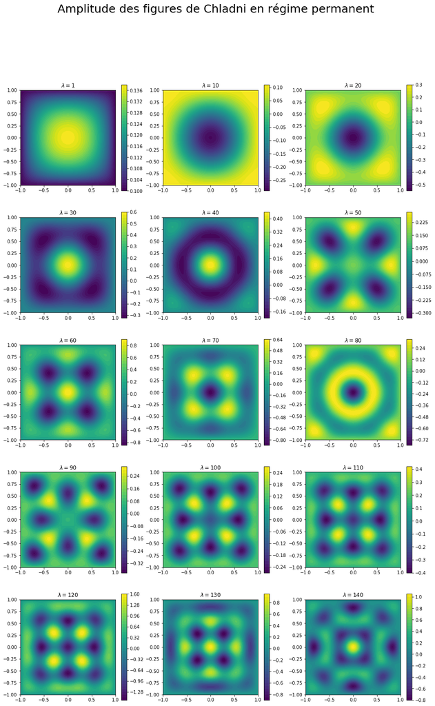

```python
list_lambda = [1] + [i for i in range(10,141,10)]
show_plot(mesh, V, bc, list_lambda, directory='Plaque - Comparaison', filename='plaque_comparaison')
```

**Description de la simulation :**  
On observe que le nombre de noeuds / ventres et leurs localisations varient en fonction du mode propre en question. Observons également que comme ici le domaine est sans défaut et présentant un haut degré de symétrie, on retrouve également des symétries axiales pour les figures de Chladni par rapport à l'axe des abscisses, des ordonnées et des 2 diagonales du domaine. Ceci n'est que peu surprenant car l'équation d'onde est clairement linéaire et la symétrie est conservée.

# Introduction du caractère aléatoire pour le domaine

**Intérêt de la composante aléatoire choisie :**  
Lorsque nous travaillerons sur le corps de guitare, nous pourrons voir l'impact de fissures, considérées ici pour simplifier comme des trous, sur la répartition des modes en son sein.

```python
def get_random_drilled_surface(domain, min_nb_holes, max_nb_holes):
    ''' Renvoie un objet de type mshr qui correspond au domaine pour la résolution de l'EDP.
    Ce domaine sera le même que celui donné en entrée, à la différence près que des
    défauts y seront ajoutés de la manière suivante :
        - Sont ajoutés un nombre aléatoire de trous (jusqu'à max_nb_holes)
        - Chaque trou a un rayon tiré uniformément dans l'intervale [0.05, 0.3].

    Inputs:
        - domain: domaine de départ que l'on veut percer (pas de side-effect)
            IMPORTANT: Il faut que les dimensions du domaine soit à peu près de l'ordre de l'unité
                car les trous seront réalisés au voisinage d'un carré de sommets (1,1), (-1,1), (-1,-1), (1,-1).
        - min_nb_holes: Nombre minimum de trous
        - max_nb_holes: Nombre maximum de trous.
    '''

    nb_holes = np.random.randint(0, max_nb_holes)

    hole_centers = np.random.uniform(-1, 1, size=(nb_holes, 2))
    hole_sizes = np.random.uniform(0.05, 0.3, size=(nb_holes))

    for i in range(nb_holes):
        domain = domain - Circle(Point(hole_centers[i, 0], hole_centers[i, 1]), hole_sizes[i])

    return domain
```

```python
domain_drilled = get_random_drilled_surface(domain, min_nb_holes = 1, max_nb_holes = 5)
mesh = generate_mesh(domain_drilled, 150)

V = FunctionSpace(mesh, 'P', 2)
```

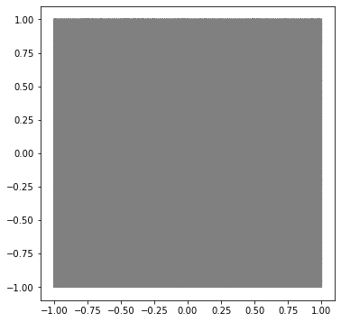

```python
plt.figure(figsize=(6,6))
plot(mesh)
```

```python
# Le choix de la valeur sur les bords est arbitraire, il faut juste imposer une Condition Limite non nulle pour
# ne pas retomber sur la solution nulle !
u_0 = Constant(1.0)

def boundary(x, on_boundary):
    return on_boundary

bc = DirichletBC(V, u_0, boundary)
```

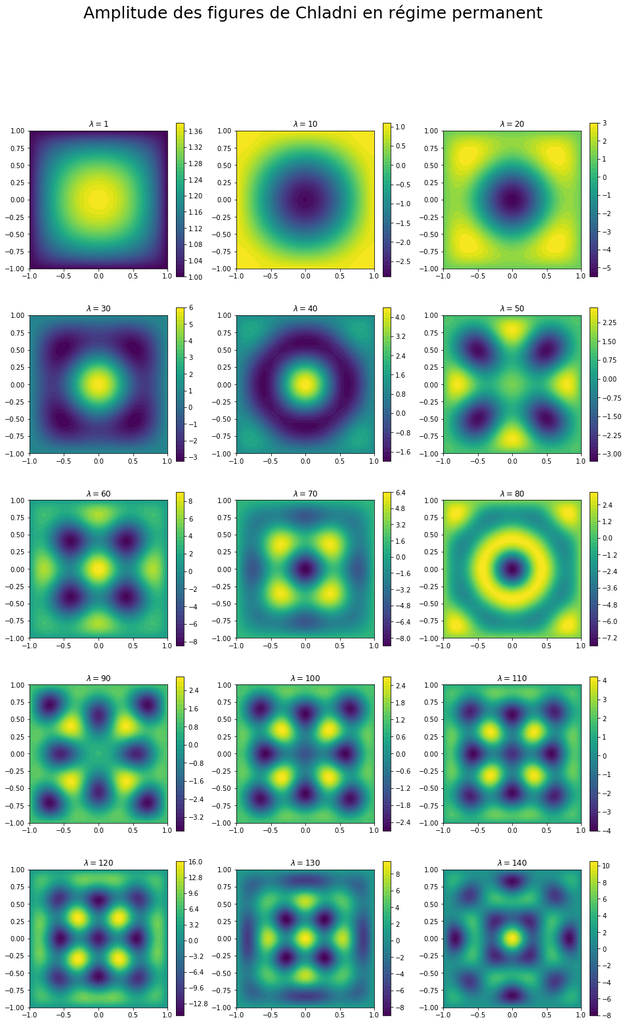

```python
show_plot(mesh, V, bc, list_lambda, directory='Plaque trouée - Comparaison', filename='plaque_trouée_comparaison')
```

# Obtention d'un maillage pour un corps de guitare

## Paramètres géométriques

Ces paramètres ont été extraits de *Engineering the Guitar: Theory and Practice* (cf bibliographie), plus précisément des pages 156 et 157.

```python
c0 = 5.1089
c1 = -0.008905
c2 = -0.109811
c3 = 0.000019328
c4 = 0.00270999
c5 = 2.4455e-6
c6 = 1.2824e-5
c7 = 2.3384e-7
c8 = 2.1193e-6
c9 = 1.6911e-10
```

## Tracé du résultat obtenu

**Equation de la moitié droite de la guitare :**

\begin{equation} R(\theta)=\frac{L}{25.5}\left[\frac{c_{0}+c_{2} \theta+c_{4} \theta^{2}+c_{6} \theta^{3}+c_{8} \theta^{4}}{1+c_{1} \theta+c_{3} \theta^{2}+c_{5} \theta^{3}+c_{7} \theta^{4}+c_{9} \theta^{5}}\right] \end{equation}

où $\theta$ est l'angle en degrés et $L$ un facteur de proportionnalité quelconque.

On choisit L pour avoir un ordre de grandeur du domaine de l'unité. $L=3$ convient.  
On obtient l'autre moitié de la guitare par simple symétrie axiale.

```python
def f(x):
    num = c0 + c2 * x + c4 * x**2 +c6 * x**3 + c8 * x**4
    den = 1 + c1 * x + c3 * x**2 + c5 * x**3 + c7 * x**4 + c9 * x**5

    return 3 * num / (den * 25.5)

f = np.vectorize(f)
```

```python
Theta = np.linspace(-0.5 * np.pi, 0.5 *np.pi, 1000)
ThetaDeg = 180 * Theta / np.pi
RR = f(ThetaDeg)
```

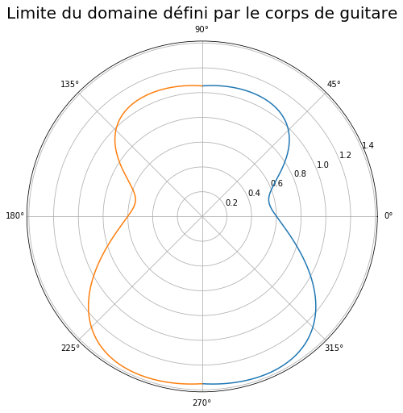

```python
plt.figure(figsize=(8,8))
plt.axes(polar = True)
plt.plot(Theta, RR)
plt.plot(np.pi - Theta, RR)
plt.title('Limite du domaine défini par le corps de guitare', fontsize=20);
```

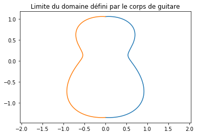

```python
def polar_to_cartesian(r, theta):
    z = cmath.rect(r, theta)
    return z.real, z.imag

plt.axes(polar = False)
XX, YY = np.vectorize(polar_to_cartesian)(RR, Theta)
XX2, YY2 = np.vectorize(polar_to_cartesian)(RR, np.pi - Theta)
plt.plot(XX, YY)
plt.plot(XX2, YY2)
plt.axis('equal')
plt.title('Limite du domaine défini par le corps de guitare');
```

On va maintenant concaténer (XX2, YY2) à (XX, YY) pour que les points soient bien les uns à la suite des autres lorsque l'on générera le mesh associé.  
On pensera à ne pas ajouter les 2 points qui se trouvent sur l'axe de symétrie et qui apparaissent donc à la fois dans XX et dans XX2 (respectivement YY et YY2).

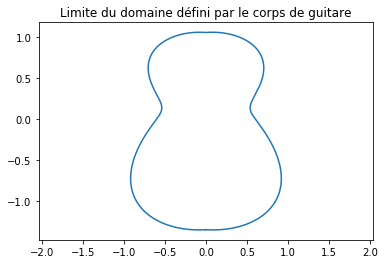

```python
XX3 = np.concatenate((XX,XX2[-2:1:-1]))
YY3 = np.concatenate((YY,YY2[-2:1:-1]))

plt.plot(XX3, YY3)
plt.axis('equal')
plt.title('Limite du domaine défini par le corps de guitare');
```

**Condition nécessaire (pour la suite) pour utiliser la fonction `generate_mesh`de *mshr* :**  
Polygon vertices must be given in counter clockwise order.

C'est déjà le cas mais on va s'en donner l'intuition dans le tracé ci-dessous.

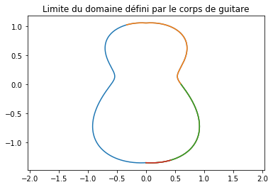

```python
plt.plot(XX3, YY3)
plt.plot(XX3[:1100],YY3[:1100])
plt.plot(XX3[:500],YY3[:500])
plt.plot(XX3[:100],YY3[:100])

plt.axis('equal')
plt.title('Limite du domaine défini par le corps de guitare');
```